# Sesion 19 - Datos Categoricos y Modelos de Grafos Probabilisticos Parte 2/7

Juan Carlos Martínez-Ovando

Maestría en Ciencia de Datos

Primavera 2019

# 1 Objetivos

En esta sesion:

- Estudiaremos definiciones y propiedades teoricas de los **modelos de grafos probabilisticos.**
- Implementaremos las soluciones con las librerias `gRbase`, `gRain` y `gRim`:

```
if(!requireNamespace("BiocManager", quietly = TRUE)){install.packages("BiocManager")}
BiocManager::install("graph", version = "3.8")
BiocManager::install("RBGL", version = "3.8")
BiocManager::install("Rgraphviz", version = "3.8")

install.packages("gRbase", dependencies=TRUE)
install.packages("gRain", dependencies=TRUE)
install.packages("gRim", dependencies=TRUE)
```

# 2 Modelos de grafos probabilisticos

Iniciaremos con el estudio de la **medida de probabilidad conjunta** para $J$ variables/dimensiones,
$$\mathbb{P}(X_1,\ldots,X_J),$$
para la cual todas las versiones marginales reducidas existen.

Recordemos que el soporte de cada $X_j$, es
$$\mathcal{X}_j=\{1,2,\ldots,K_j\},$$
para $j=1,\ldots,J$.

Estudiaremos algunas propiedades relevantes para la especificacion de esta medida de probabilidad conjunta, en particular:

- Independencia condicional
- Direccion de asociaciones.

## 2.1 Independencia condicional

Para un conjunto de dos variables/dimensiones, $X_1$ y $X_2$, se dira que son **independientes** si
$$\mathbb{P}(X_1,X_2)=\mathbb{P}(X_1) \mathbb{P}(X_2).$$

Por consecuencia, tendremos
$$\mathbb{P}(X_1|X_2)=\mathbb{P}(X_1),\\
\mathbb{P}(X_2|X_1)=\mathbb{P}(X_2).$$

Denotaremos cuando dos variables/dimensiones son independientes, como en el caso anterior, de la forma,
$$X_1 \mathrel{\text{$\perp\mkern-10mu\perp$}}X_2.$$

### 2.1.1 Independencia condicional

Considerando tres variables/dimensiones, $X_1$, $X_2$ y $X_3$, diremos que $X_1$ y $X_2$ son condicionalmente independientes dado $X_3$, si
$$\mathbb{P}(X_1,X_2|X_3)=\mathbb{P}(X_1|X_3) \mathbb{P}(X_2|X_3).$$
En este caso, tal relacion se denotara como
$$(X_1 \mathrel{\text{$\perp\mkern-10mu\perp$}}X_2) \ | \ X_3,$$
para **todos los valores de** $X_3$. De manera analoga al caso de independencia, tendremos
$$\mathbb{P}(X_1|X_2,X_3)=\mathbb{P}(X_1|X_3),\\
\mathbb{P}(X_2|X_1,X_3)=\mathbb{P}(X_2|X_3).$$

> Este resultado se generaliza para bloques de variables/dimensiones definidos de manera arbitraria.

### 2.1.2 Factorizacion

En el caso de independencia condicional,
$$(X_1 \mathrel{\text{$\perp\mkern-10mu\perp$}}X_2) \ | \ X_3$$
, sera obtenida si la medida de probabilidad conjunta para $(X_1,X_2,X_3)$ puede **factorizarse** de la siguiente forma
$$\mathbb{P}(X_1,X_2,X_3)=f(X_1,X_3)g(X_2,X_3),$$
para dos funciones $f(\cdot)$ y $g(\cdot)$ positivas.

### 2.1.3 Ejemplo de factorizacion

Considerando $(X_1,X_2,X_3)$ tres variables/dimensiones discretas, definimos
$$\theta_{ijk}=\mathbb{P}(X_1=i,X_2=j,X_3=k),$$
con $i\in \mathcal{X}_1$, $j\in \mathcal{X}_2$ y $k\in \mathcal{X}_3$.

Si expresamos $\theta_{ijk}$ como
$$\log \theta_{ijk} = \alpha_{1,i} + \alpha_{2,j} + \alpha_{3,k} + \beta_{12,ij} + \beta_{23,jk},$$
para todo $i,j,k$, tenemos que podemos expresar $\theta_{ijk}$ de la forma,
$$\theta_{ijk}=f(i,k)g(j,k),$$
para todo $i,j,k$.

Por lo que se cumple que
$$(X_1 \mathrel{\text{$\perp\mkern-10mu\perp$}}X_2) \ | \ X_3.$$

> La especificacion de este modelo corresponde a un caso particular de los **modelos log-lineales**. Mas adelante los definiremos con precision.

# 3 Grafos no dirigidos

## 3.1 Asociaciones

> **Definicion:-** Un **grafo** es un objeto matematico de un par de `vertices/nodos/variables/dimensiones`, $V$, y un conjunto de `bordes/conectores`, $E$. El drafo se denota por $\mathcal{G}=(V,E)$.

Un **borde** se define como una `conexion` entre dos `nodos`.

> Cuando los **bordes** solo conectan nodos, pero sin direccion, se dice que $\mathcal{G}$ es un **grafo no dirigido**.

> **Definicion:-** Dada una coleccion de `nodos/vertices`, $V$, y una coleccion $\mathcal{A}=\{a_1,\ldots, a_Q\}$ de $V$ ($a_l \subset V$) tal que $\cup_{l}a_l=V$, el **grafo generado por** $\mathcal{A}$ se define como
> $$\mathcal{G}(\mathcal{A})=(V,E),$$
> donde $E$ es definido como $\{a,b\}\in E$ si-y-solo-si $\{a,b\}\subset a_l$ para algun $l$.

En `R` podemos `crear` y `visualizar` grafos no dirigidos de la siguiente las funciones `ug` y `plot`.

Para este ejemplo, consideramos que los `nodos/dimensiones` por relacionar corresponden a los indices
$$\{1,2,3,4,5,6,7\},$$
con la estructura de asociacion particular.

```r
suppressMessages(library("gRbase"))
suppressMessages(library("Rgraphviz"))

g1 <- ug(~1:2:5 + 1:3:5 + 2:4:5 + 3:4:5 + 3:7 + 4:6)
class(g1)
```

```
## [1] "graphNEL"
## attr(,"package")
## [1] "graph"
```

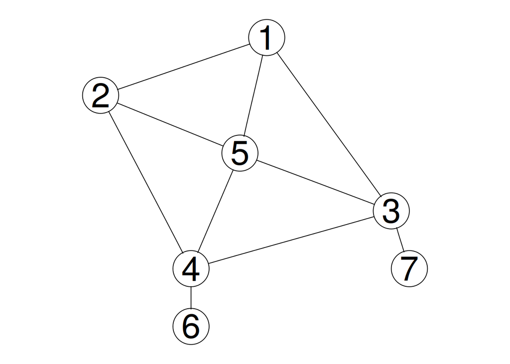

```r
plot(g1)
```

## 3.2 Matrices de adyacencia

> Los `nodos` y `bordes` de un grafo pueden ser definidos a partir de las **matrices de adyacencia**, que son matrices cuadradas de dimension $J\times J$ en las que se define la asociacion entre nodos correspondientes.

A continuacion, definimos una matriz de adyacencia para cinco `nodos`,
$$\{1,2,3,4,5\}.$$
Con la funcion `as()` se le asigna atributos un *objeto de grafo*, `graphNEL`.

```r
m <- matrix(c(0, 1, 1, 0, 1,
              1, 0, 0, 1, 1,
              1, 0, 0, 1, 1,
              0, 1, 1, 0, 1,
              1, 1, 1, 1, 0), nrow = 5)
rownames(m) <- colnames(m) <- c("1", "2", "3", "4", "5")
m
```

```
##   1 2 3 4 5
## 1 0 1 1 0 1
## 2 1 0 0 1 1
## 3 1 0 0 1 1
## 4 0 1 1 0 1
## 5 1 1 1 1 0
```

```r
as(m, "graphNEL")
```

```
## A graphNEL graph with undirected edges
## Number of Nodes = 5
## Number of Edges = 8
```

## 3.3 Modificacion de grafos

Los `bordes` de un grafo pueden *modificarse* (quitando o anadiendolos) de la siguiente forma

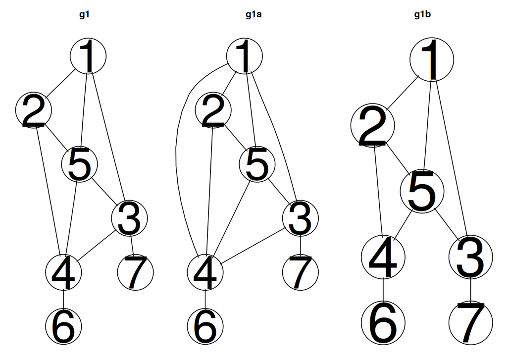

```r
g1a <- addEdge("1", "4", g1)
g1b <- removeEdge("3", "4", g1)

par(mfrow = c(1, 3))
plot(g1, main = "g1")
plot(g1a, main = "g1a")
plot(g1b, main = "g1b")
```

## 3.4 Subgrafos

Cada parte de un grafo sera a su vez un grafo en si mismo, de acuerdo a la siguiente definicion.

> **Definicion:-** Un **subgrafo** $\mathcal{G}'=(V',E')$ de $\mathcal{G}=(V,E)$ es definido asi si $V' \subset V$ y $E'\subset E$.

De manera analoga, si consideramos un subconjunto de `vertices` $A\subset V$, entonces este subconjunto definira un `subgrafo` del grafo donde $V$ este definido.

> **Definicion:-** El **subgrafo inducido** por $A\subset V$ de $\mathcal{G}=(V,E)$ es definido como $\mathcal{G}_A=(A,E_A)$, donde $E_A$ es el conjunto de `nodos` asociados con los vertices en $A$.

Del grafo que hemos definido antes, `g1`, podemos extraer el subgrafo asociado con
$$A=\{2,3,4,5\},$$
de la siguiente forma.

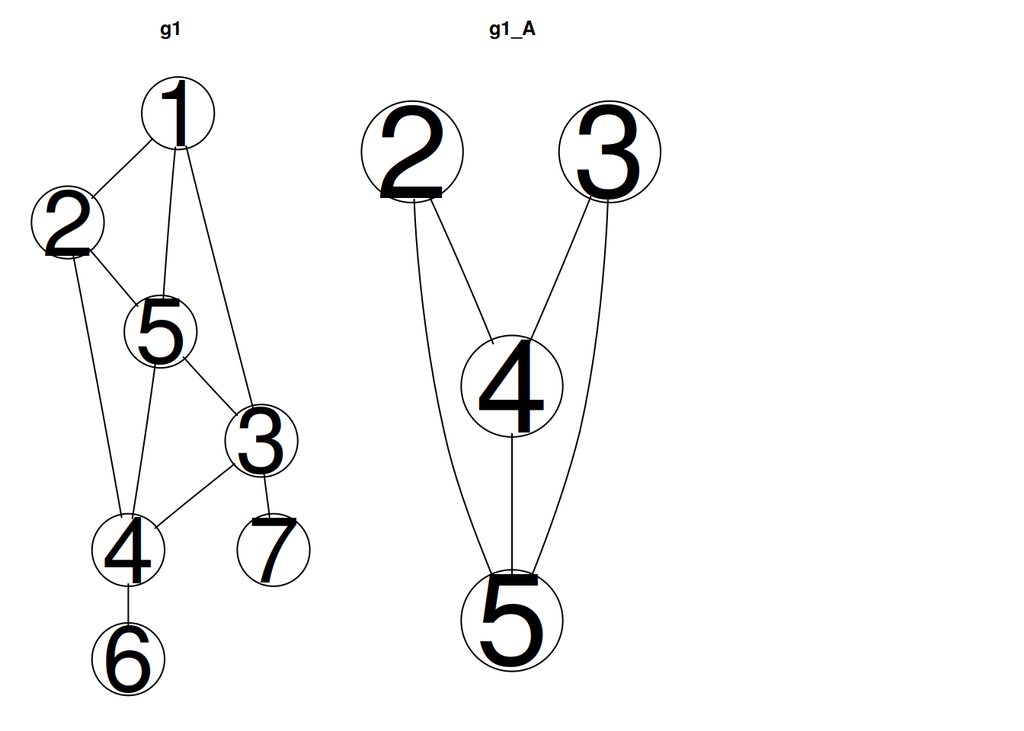

```r
g1_A <- subGraph(c("2", "3", "4", "5"), g1)

par(mfrow = c(1, 3))
plot(g1, main = "g1")
plot(g1_A, main = "g1_A")
```

## 3.5 Cliques

Los `cliques` de un grafo se definen, *grosso modo*, como el subgrafo asociado con `vertices` y `nodos` completamente conectados.

> **Definicion:-** Un subconjunto de vertices $C\subset E$ de $\mathcal{G}$ es **completo** si todos los pares de vertices en $C$ estan conectados por un `borde`.

Diremos que un grafo $\mathcal{G}=(V,E)$ es completo si $V$ es un conjunto completo de vertices.

> Un **clique** de un grafo $\mathcal{G}$ es un **subgrafo completo** que no esta contenido en otro grafo completo mas grande.

Es decir, un **clique** es un *subgrafo completo maximal*.

Podemos preguntarnos si un grafo dado es *completo maximal* o no. Por ejemplo, para el grafo `g1` anterior, tenemos:

```r
is.complete(g1)
```

```
## [1] FALSE
```

Este resultado no es sorprendente, ya lo habiamos notado por los extremos `6` y `7`.

Ahora bien, el sugrafo inducido por
$$B=\{1,2,5\},$$
si es completo.

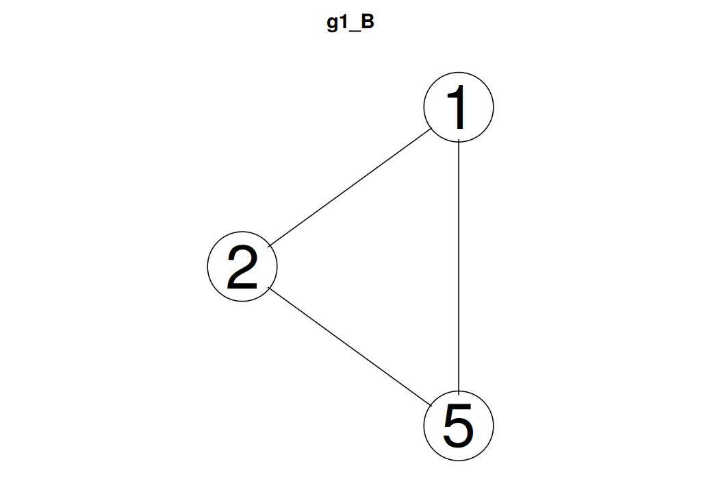

```r
g1_B <- subGraph(c("1", "2", "5"), g1)

plot(g1_B, main = "g1_B")
```

```r
is.complete(g1_B)
```

```
## [1] TRUE
```

Pero este no es el unico subgrafo completo de `g1`, veamos:

```r
library("RBGL")
maxClique(g1)
```

```
## $maxCliques
## $maxCliques[[1]]
## [1] "5" "2" "1"
##
## $maxCliques[[2]]
## [1] "5" "2" "4"
##
## $maxCliques[[3]]
## [1] "5" "3" "1"
##
## $maxCliques[[4]]
## [1] "5" "3" "4"
##
## $maxCliques[[5]]
## [1] "7" "3"
##
## $maxCliques[[6]]
## [1] "6" "4"
```

```r
str(maxClique(g1))
```

```
## List of 1
##  $ maxCliques:List of 6
##   ..$ : chr [1:3] "5" "2" "1"
##   ..$ : chr [1:3] "5" "2" "4"
##   ..$ : chr [1:3] "5" "3" "1"
##   ..$ : chr [1:3] "5" "3" "4"
##   ..$ : chr [1:2] "7" "3"
##   ..$ : chr [1:2] "6" "4"
```

## 3.6 Separacion

En estas propedades, estudiaremos si es posible ver a un grafo $\mathcal{G}=(V,E)$ como subgrafos ajenos. Esta propiedad se define tn terminos de los `vertices`.

> Se dice que un subconjunto $S\subset V$ es separado de otro subconjunto $R\subset V$ si ningun vertice en $S$ esta conectado con los vertices en $R$.

La conexion de vertices se define en terminos de las **trayectorias** entre dos vertices $v_1$ y $v_2$ en **grafos no dirigidos**, definidas como el conjunto de vertices $\{a_0,\ldots,a_n\}$ tales que

- $a_0=v_1$, $a_n=v_2$
- $\{a_{j-1},a_j\}\in E$ definen un `borde`, para $j=1,\ldots, n$.

En este caso, $n$ define la **longitud de la trayectoria**.

**Observen:-** Las trayectorias pueden no ser unicas.

**Observen:-** Algunas trayectorias pueden ser ciciclas, cuando algun $a_j$ de la trayectoria corresponde a $v_1$ o $v_2$.

> Se dice que un sunconjunto $S\subset V$ **separa a dos sunconjuntos ajenos** $A,B\subset V$ si toda trayectoria de un vertice en $A$ y otro vertice en $B$ incluye un `borde` con un vertice en $S$.

Por ejemplo, creamos el grafo `g2`,

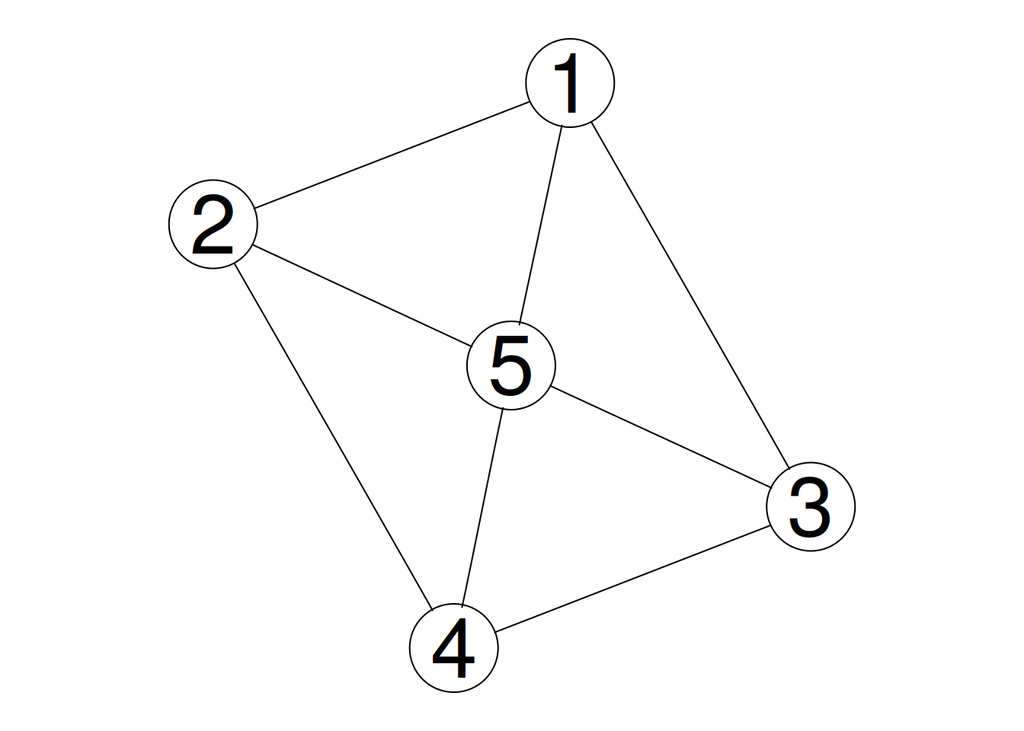

```r
g2 <- ug(~1:2:5 + 1:3:5 + 2:4:5 + 3:4:5)
plot(g2)
```

y evaluamos si el conjunto $A=\{1\}$ y $B=\{4\}$ son separados por $S=\{2,3,5\}$:

```r
separates("1", "4", c("2", "3", "5"), g2)
```

```
## [1] TRUE
```

Pero, por ejmplo, $A=\{1,2\}$ y $B=\{3,4\}$ no son separados por $S=\{5\}$:

```r
separates(c("1","2"), c("3","4"), c("5"), g2)
```

```
## [1] FALSE
```

## 3.7 Grafo de dependencia

Regresando a version probabilistica del modelo de grafos, vinculemos las nociones anteriores con sus implicaciones sobre $\mathbb{P}(\cdot)$.

Consideremos un **grafo probabilisitico** $J$-dimensional, para las variables
$$X=\{X_j:j\in V\},$$
donde
$$V=\{1,\ldots,J\}.$$

El sunconjunto de variables aleatorias inducidas por un subconjunto $A\subset V$ es definido como
$$\{X_j:j\in A\}.$$

> Definimos la coleccion de subconjunto de $V$ como $\mathcal{A}=\{A:A\subset V\}$ tales que $\cup_{A\in\mathcal{A}}=V$.

El soporte de las variables aleatorias en $X$ es definido como
$$\mathcal{X}=\mathcal{X}_1 \times \cdots \times \mathcal{X}_J,$$
donde $\mathcal{X}_j=\{1,\ldots,K_j\}$.

> La **funcion de masas de probabilidades** para $X$ se define como
> $$\mathbb{P}(X=x)=p(x)=\prod_{A\in \mathcal{A}}\phi_A(x_A),$$
> donde $x_A$ son las coordenadas de $x$ asociadas con el subconjunto $A$.
- En este caso, la funcion $\phi(\cdot)$ no es una medida de probabilidad, necesariamente, solo requiere ser positiva.

> **Definicion:-** El **grafo de dependencia** para $\mathbb{P}(\cdot)$ (o, analogamente, para $p(\cdot)$) es el **grafo** asociado con $\mathcal{A}$.

### 3.7.1 Ejemplo

Supongamos que $J=6$ con la siguiente representacion para $p(\cdot)$,
$$p(x)=p(x_1,x_2,x_3,x_4,x_5)=\phi_{1,2}(x_1,x_2)\phi_{2,3,4}(x_2,x_3,x_4)\phi_{3,5}(x_3,x_5)
\phi_{4,5}(x_4,x_5)\phi_{6}(x_6).$$

Entonces, el `grafo de dependencia` para $p(\cdot)$, denota por `g3`, es definido como:

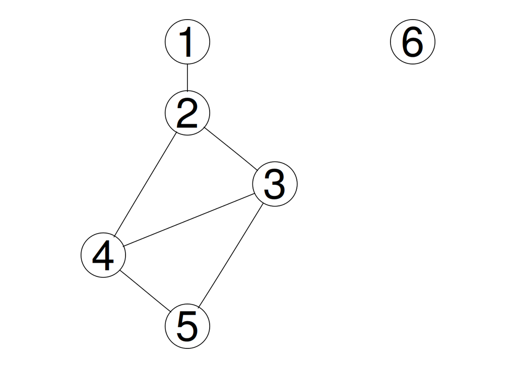

```r
g3 <- ug(~ 1:2 + 2:3:4 + 3:5 + 4:5 + 6)
plot(g3)
```

En el caso anterior la dimension $X_6$ es aislada, lo que induce que esta dimension sea `independiente estocasticamente` de las restantes bajo $p(\cdot)$.

## 3.8 Propiedad de Markov

La nocion de **simetria estocastica** entre las $J$ dimensiones de $X$ a traves de $\mathbb{P}(\cdot)$ (o $p(\cdot)$) se **especifica** o se **extrae** del **grafo de dependencia asociado.**

En particular, si $\mathcal{G}=(V,E)$ es el **grafo de dependencia** asociado con $p(\cdot)$, y existen subconjuntos
$$A\subset V,\\
B\subset V,$$

separados por otro subconjunto
$$S\subset V,$$
entonces, $X_A$ y $X_B$ seran condicionalmente independientes dado $X_S$, i.e.
$$(X_A \mathrel{\text{$\perp\mkern-10mu\perp$}}X_B) \ | \ X_S.$$

De acuerdo a lo anterior, la probabilidad $p(x_A,x_B,x_S)$ cumplira con la **factorizacion**,
$$p(x_A,x_B,x_S)=\phi_{A,S}(x_A,x_S)\phi_{B,S}(x_B,x_S).$$

### 3.8.1 Ejemplo

Retomando el ejemplo anterior con `g3`, podemos ver que
$$p(x)=p(x_1,x_2,x_3,x_4,x_5,x_6)=\left\{\phi_{1,2}(x_1,x_2)\right\} \times \left\{\phi_{2,3,4}(x_2,x_3,x_4)\phi_{3,5}(x_3,x_5)\phi_{4,5}(x_4,x_5)\right\}\times\left\{\phi_{6}(x_6)\right\},$$
por lo que integrando $X_3$ y $X_6$ tenemos que
$$(X_{1} \mathrel{\text{$\perp\mkern-10mu\perp$}}X_{4,5}) \ | \ X_{2},$$
con
$$X_{4,5}=(X_{4},X_{5}).$$

Este resultado es extraido de `g3`, de la siguiente forma:

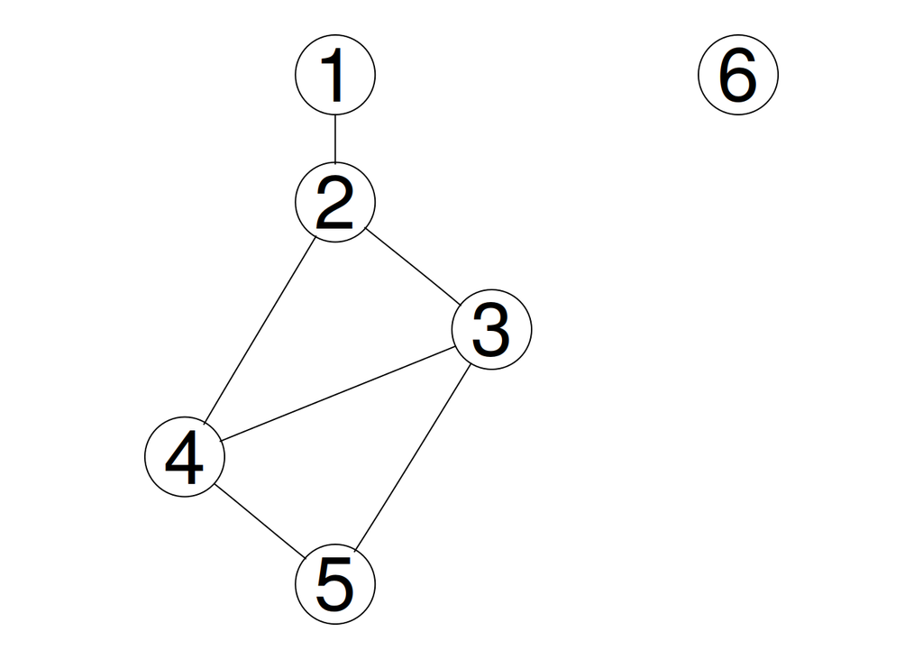

```r
plot(g3)
```

```r
separates(c("4","5"), "1", "2", g3)
```

```
## [1] TRUE
```

# 4 Siguiente sesion

En la siguiente sesion:

- Estudiaremos la especificacion de los modelos log-lineales para tablas de contingencia de $2\times 2$ como un modelo de grafos probabilisticos.
- Estudiaremos la extension de estas especificaciones para tablas de contingencia multiples (*multi-way contingency tables*).

# 5 Lecturas complementarias

- Nota personal sobre tablas de contingencia $2\times 2$. `est46114_s19_suplemento1.pdf`
- Coppi, *An Introduction to Multi-Way Data and Their Analysis.* `est46114_s19_suplemento2.pdf`